# LDFS_200709

JeongMin Park

2020-7-9

## 데이터 불러오기

```r
setwd('C:/Users/jeong/Desktop/ldfs')
library(readr)
library(tidyverse)
library(lubridate)
data <- read_csv('매출 데이터_매출변환후.csv')
weekday <- read_csv('날짜 데이터.csv')
weekday$기준일자 <- as.Date(as.character(weekday$기준일자), '%Y%m%d')

head(data)
```

| 기준일자 | 기준일시 | 교환권번호 | 회원ID | 국가코드 | VIP등급 | 성별 | 연령 | 연령대 | 상품코드 | 상품명 | 카테고리코드 | 카테고리명 | 브랜드코드 | 브랜드명 | 럭셔리브랜드여부 | 아이템코드 | 아이템명 | 클래스코드 | 클래스명 | 외산토산구분 | 매장위치 | 정상여부 | 매출액 | 판매단가 | 매출속성 |
| --- | --- | --- | --- | --- | --- | --- | --- | --- | --- | --- | --- | --- | --- | --- | --- | --- | --- | --- | --- | --- | --- | --- | --- | --- | --- |
| 20191227 | 2019-12-27 오후 1:18:34 | a688fc63548a28ef8176bb36e361f5929cafe4c0 | d229695a7c562b546a94d43738b7553688e1b1c7 | RST | G | 2 | 61 | 6 | 2061872633 | BOBBI BR COS EA6C | 12 | COS and PFM | 145981 | BOBBI BROWN | 0 | 6 | 화장품 | 22 | 메이크업(페이스) | 외산 | 12층 | 1 | 0.0006273372 | 3.306505e-04 | FIT |
| 20191202 | 2019-12-02 오후 5:51:03 | 54ea72fa6a7d52f796baae2fbb0b5e55cf721488 | 3bdc5e5a515c8093082ed662ca827e3c2bdc7783 | RST | G | 2 | 64 | 6 | 2726418886 | 이니스프 COS 비비드코튼잉크19호(19) | 12 | COS and PFM | 207810 | Innisfree | 0 | 6 | 화장품 | 24 | 메이크업(립) | 토산 | 11층 | 0 | NA | NA | FIT |
| 20191202 | 2019-12-02 오후 5:55:53 | 8ab15560d76535785bb726a2fdbc927a62c03dac | 3bdc5e5a515c8093082ed662ca827e3c2bdc7783 | RST | G | 2 | 64 | 6 | 2726418886 | 이니스프 COS 비비드코튼잉크19호(19) | 12 | COS and PFM | 207810 | Innisfree | 0 | 6 | 화장품 | 24 | 메이크업(립) | 토산 | 11층 | 0 | NA | NA | FIT |
| 20191231 | 2019-12-31 오후 3:50:04 | 5c20fbabd6edf7e8950e685c7cd1dd033ca3205f | 9ce6acd485dc2e018271812bb26802d0cc6e8a60 | JPN | G | 2 | 64 | 6 | 2069521922 | N.FAMILY FDpk NFGOM 240S | 16 | FOOD | 154878 | N.FAMILY | 0 | 20 | 식품 | 28 | 식품기타 | 외산 | 9층 | 0 | NA | NA | FIT |
| 20191231 | 2019-12-31 오후 3:52:24 | 927321285fe6e3dee2f23bf24415c31c12a76a39 | 9ce6acd485dc2e018271812bb26802d0cc6e8a60 | JPN | G | 2 | 64 | 6 | 2069521922 | N.FAMILY FDpk NFGOM 240S | 16 | FOOD | 154878 | N.FAMILY | 0 | 20 | 식품 | 28 | 식품기타 | 외산 | 9층 | 1 | 0.0007413986 | 9.677575e-04 | FIT |
| 20191226 | 2019-12-26 오전 11:50:42 | 9e39383f0401a5b01ce068ecdbff432fb86519e0 | 29a9902a19d796c8d18f39773aa0f97d3d909c58 | RST | G | 2 | 47 | 4 | 2722906356 | 3CE COS 백투베이비 글로우 빔 #핑크 | 12 | COS and PFM | 300585 | 3CONCEPT EYES | 0 | 6 | 화장품 | 22 | 메이크업(페이스) | 토산 | 11층 | 1 | 0.0001059141 | 9.677575e-05 | FIT |

```r
summary(data)
```

```
##     기준일자          기준일시          교환권번호
##  Min.   :20191201   Length:1224795     Length:1224795
##  1st Qu.:20191209   Class :character   Class :character
##  Median :20191216   Mode  :character   Mode  :character
##  Mean   :20191216
##  3rd Qu.:20191223
##  Max.   :20191231
##
##     회원ID            국가코드           VIP등급               성별
##  Length:1224795     Length:1224795     Length:1224795     Min.   :1.000
##  Class :character   Class :character   Class :character   1st Qu.:2.000
##  Mode  :character   Mode  :character   Mode  :character   Median :2.000
##                                                           Mean   :1.798
##                                                           3rd Qu.:2.000
##                                                           Max.   :2.000
##
##       연령          연령대             상품코드            상품명
##  Min.   : 14.0   Length:1224795     Min.   :2.013e+09   Length:1224795
##  1st Qu.: 31.0   Class :character   1st Qu.:2.067e+09   Class :character
##  Median : 42.0   Mode  :character   Median :2.070e+09   Mode  :character
##  Mean   :467.6                      Mean   :2.307e+09
##  3rd Qu.:999.0                      3rd Qu.:2.725e+09
##  Max.   :999.0                      Max.   :2.727e+09
##
##   카테고리코드    카테고리명          브랜드코드       브랜드명
##  Min.   :11.00   Length:1224795     Min.   :    16   Length:1224795
##  1st Qu.:12.00   Class :character   1st Qu.:   325   Class :character
##  Median :12.00   Mode  :character   Median :183660   Mode  :character
##  Mean   :12.33                      Mean   :159732
##  3rd Qu.:12.00                      3rd Qu.:300585
##  Max.   :19.00                      Max.   :303011
##
##  럭셔리브랜드여부    아이템코드       아이템명           클래스코드
##  Min.   :0.00000   Min.   : 1.000   Length:1224795     Min.   : 1.00
##  1st Qu.:0.00000   1st Qu.: 6.000   Class :character   1st Qu.:21.00
##  Median :0.00000   Median : 6.000   Mode  :character   Median :21.00
##  Mean   :0.05899   Mean   : 6.798                      Mean   :20.86
##  3rd Qu.:0.00000   3rd Qu.: 6.000                      3rd Qu.:24.00
##  Max.   :1.00000   Max.   :33.000                      Max.   :68.00
##
##    클래스명         외산토산구분         매장위치
##  Length:1224795     Length:1224795     Length:1224795
##  Class :character   Class :character   Class :character
##  Mode  :character   Mode  :character   Mode  :character
##
##
##
##
##     정상여부           매출액         판매단가       매출속성
##  Min.   :-1.0000   Min.   :0       Min.   :0       Length:1224795
##  1st Qu.: 1.0000   1st Qu.:0       1st Qu.:0       Class :character
##  Median : 1.0000   Median :0       Median :0       Mode  :character
##  Mean   : 0.9662   Mean   :0       Mean   :0
##  3rd Qu.: 1.0000   3rd Qu.:0       3rd Qu.:0
##  Max.   : 1.0000   Max.   :1       Max.   :1
##                    NA's   :41328   NA's   :41328
```

```r
dim(data)
```

```
## [1] 1224795      26
```

## 데이터 전처리

```r
data$기준일자 <- as.Date(as.character(data$기준일자), '%Y%m%d')
data <- data %>% separate(기준일시, into=c('date', 'P', 'time'), sep=' ') %>%
  mutate(hour=ifelse(P=='오후', hour(strptime(time, '%I:%M:%S'))+12,
                     hour(strptime(time, '%I:%M:%S'))))
data$국가코드 <- as.factor(data$국가코드)
data$VIP등급 <- as.factor(data$VIP등급)
data$성별 <- as.factor(data$성별)
data$연령대 <- as.factor(data$연령대)
data$카테고리코드 <- as.factor(data$카테고리코드)
data$브랜드코드 <- as.factor(data$브랜드코드)
data$럭셔리브랜드여부 <- as.factor(data$럭셔리브랜드여부)
data$아이템코드 <- as.factor(data$아이템코드)
data$클래스코드 <- as.factor(data$클래스코드)
data$외산토산구분 <- as.factor(data$외산토산구분)
data$매장위치 <- as.factor(data$매장위치)
data$정상여부 <- as.factor(data$정상여부)
data$매출속성 <- as.factor(data$매출속성)

weekday$요일명 <- as.factor(weekday$요일명)
weekday$주중주말1 <- as.factor(weekday$주중주말1)
```

## 데이터 합치기

```r
data <- data %>% left_join(weekday)

summary(data)
```

```
##     기준일자              date                P
##  Min.   :2019-12-01   Length:1224795     Length:1224795
##  1st Qu.:2019-12-09   Class :character   Class :character
##  Median :2019-12-16   Mode  :character   Mode  :character
##  Mean   :2019-12-16
##  3rd Qu.:2019-12-23
##  Max.   :2019-12-31
##
##      time            교환권번호           회원ID
##  Length:1224795     Length:1224795     Length:1224795
##  Class :character   Class :character   Class :character
##  Mode  :character   Mode  :character   Mode  :character
##
##
##
##
##     국가코드       VIP등급    성별            연령       연령대
##  CHN    :1123098   G:574708   1:247289   Min.   : 14.0   1:  3379
##  KOR    :  35682   L:  7545   2:977506   1st Qu.: 31.0   2:238535
##  JPN    :  27347   P:369893              Median : 42.0   3:348396
##  TWN    :   9867   S: 27475              Mean   :467.6   4: 58664
##  MAS    :   5200   V:  4362              3rd Qu.:999.0   5: 16981
##  RST    :   4882   z:240812              Max.   :999.0   6:  7424
##  (Other):  18719                                         z:551416
##     상품코드            상품명           카테고리코드
##  Min.   :2.013e+09   Length:1224795     12     :926949
##  1st Qu.:2.067e+09   Class :character   11     :145592
##  Median :2.070e+09   Mode  :character   16     : 33511
##  Mean   :2.307e+09                      13     : 31727
##  3rd Qu.:2.725e+09                      19     : 28447
##  Max.   :2.727e+09                      14     : 27034
##                                         (Other): 31535
##   카테고리명          브랜드코드       브랜드명         럭셔리브랜드여부
##  Length:1224795     345    : 73387   Length:1224795     0:1152544
##  Class :character   187004 : 51156   Class :character   1:  72251
##  Mode  :character   263    : 43897   Mode  :character
##                     266    : 32636
##                     301297 : 30730
##                     164833 : 27977
##                     (Other):965012
```

[output cut: 17 more lines]

```
##  Min.   :0       FIT     :150520   Min.   : 0.00   Min.   :1.000
##  1st Qu.:0       MG      :433666   1st Qu.:12.00   1st Qu.:2.000
##  Median :0       SG      :557754   Median :15.00   Median :4.000
##  Mean   :0       일반단체: 79448   Mean   :14.56   Mean   :3.914
##  3rd Qu.:0       초청단체:  3407   3rd Qu.:17.00   3rd Qu.:6.000
##  Max.   :1                         Max.   :22.00   Max.   :7.000
##  NA's   :41328
##     요일명       주중주말1
##  금요일:166738   주말:374258
##  목요일:162619   주중:850537
##  수요일:163418
##  월요일:176158
##  일요일:198378
##  토요일:175880
##  화요일:181604
```

```r
head(data)
```

| 기준일자 | date | P | time | 교환권번호 | 회원ID | 국가코드 | VIP등급 | 성별 | 연령 | 연령대 | 상품코드 | 상품명 | 카테고리코드 | 카테고리명 | 브랜드코드 | 브랜드명 | 럭셔리브랜드여부 | 아이템코드 | 아이템명 | 클래스코드 | 클래스명 | 외산토산구분 | 매장위치 | 정상여부 | 매출액 | 판매단가 | 매출속성 | hour | 요일코드 | … |
| --- | --- | --- | --- | --- | --- | --- | --- | --- | --- | --- | --- | --- | --- | --- | --- | --- | --- | --- | --- | --- | --- | --- | --- | --- | --- | --- | --- | --- | --- | --- |
| 2019-12-27 | 2019-12-27 | 오후 | 1:18:34 | a688fc63548a28ef8176bb36e361f5929cafe4c0 | d229695a7c562b546a94d43738b7553688e1b1c7 | RST | G | 2 | 61 | 6 | 2061872633 | BOBBI BR COS EA6C | 12 | COS and PFM | 145981 | BOBBI BROWN | 0 | 6 | 화장품 | 22 | 메이크업(페이스) | 외산 | 12층 | 1 | 0.0006273372 | 3.306505e-04 | FIT | 13 | 6 | … |
| 2019-12-02 | 2019-12-02 | 오후 | 5:51:03 | 54ea72fa6a7d52f796baae2fbb0b5e55cf721488 | 3bdc5e5a515c8093082ed662ca827e3c2bdc7783 | RST | G | 2 | 64 | 6 | 2726418886 | 이니스프 COS 비비드코튼잉크19호(19) | 12 | COS and PFM | 207810 | Innisfree | 0 | 6 | 화장품 | 24 | 메이크업(립) | 토산 | 11층 | 0 | NA | NA | FIT | 17 | 2 | … |
| 2019-12-02 | 2019-12-02 | 오후 | 5:55:53 | 8ab15560d76535785bb726a2fdbc927a62c03dac | 3bdc5e5a515c8093082ed662ca827e3c2bdc7783 | RST | G | 2 | 64 | 6 | 2726418886 | 이니스프 COS 비비드코튼잉크19호(19) | 12 | COS and PFM | 207810 | Innisfree | 0 | 6 | 화장품 | 24 | 메이크업(립) | 토산 | 11층 | 0 | NA | NA | FIT | 17 | 2 | … |
| 2019-12-31 | 2019-12-31 | 오후 | 3:50:04 | 5c20fbabd6edf7e8950e685c7cd1dd033ca3205f | 9ce6acd485dc2e018271812bb26802d0cc6e8a60 | JPN | G | 2 | 64 | 6 | 2069521922 | N.FAMILY FDpk NFGOM 240S | 16 | FOOD | 154878 | N.FAMILY | 0 | 20 | 식품 | 28 | 식품기타 | 외산 | 9층 | 0 | NA | NA | FIT | 15 | 3 | … |
| 2019-12-31 | 2019-12-31 | 오후 | 3:52:24 | 927321285fe6e3dee2f23bf24415c31c12a76a39 | 9ce6acd485dc2e018271812bb26802d0cc6e8a60 | JPN | G | 2 | 64 | 6 | 2069521922 | N.FAMILY FDpk NFGOM 240S | 16 | FOOD | 154878 | N.FAMILY | 0 | 20 | 식품 | 28 | 식품기타 | 외산 | 9층 | 1 | 0.0007413986 | 9.677575e-04 | FIT | 15 | 3 | … |
| 2019-12-26 | 2019-12-26 | 오전 | 11:50:42 | 9e39383f0401a5b01ce068ecdbff432fb86519e0 | 29a9902a19d796c8d18f39773aa0f97d3d909c58 | RST | G | 2 | 47 | 4 | 2722906356 | 3CE COS 백투베이비 글로우 빔 #핑크 | 12 | COS and PFM | 300585 | 3CONCEPT EYES | 0 | 6 | 화장품 | 22 | 메이크업(페이스) | 토산 | 11층 | 1 | 0.0001059141 | 9.677575e-05 | FIT | 11 | 5 | … |

## EDA

```r
library(ggplot2)
```

### Numeric Variables

#### 기준일자

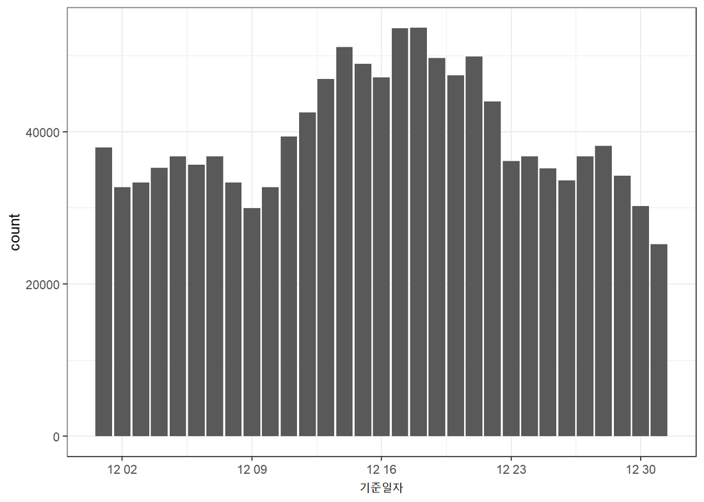

```r
ggplot(data, aes(`기준일자`)) +
  geom_bar() + theme_bw()
```

- 12월 중순에 구매건수가 가장 많음

```r
week_effect <- data %>% group_by(요일코드, 요일명) %>% count()
week_effect
```

| 요일코드 | 요일명 | n |
| --- | --- | --- |
| 1 | 일요일 | 198378 |
| 2 | 월요일 | 176158 |
| 3 | 화요일 | 181604 |
| 4 | 수요일 | 163418 |
| 5 | 목요일 | 162619 |
| 6 | 금요일 | 166738 |
| 7 | 토요일 | 175880 |

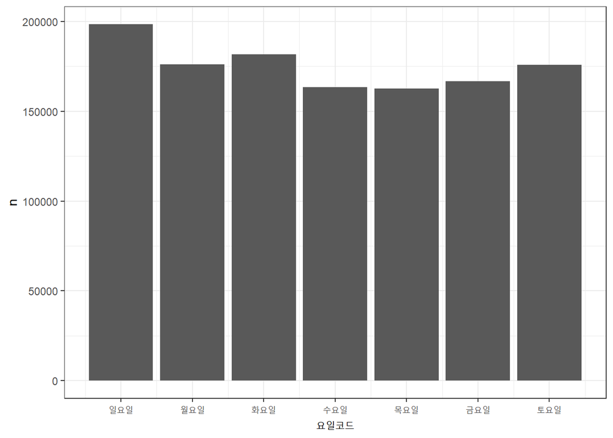

```r
ggplot(week_effect, aes(요일코드, n)) +
  geom_bar(stat = 'identity') + theme_bw() +
  scale_x_continuous(breaks = seq(1,7),
                     labels = week_effect$요일명)
```

- 일요일에 구매건수가 가장 많음 (뚜렷한 주말 효과는 없음!)

#### 연령

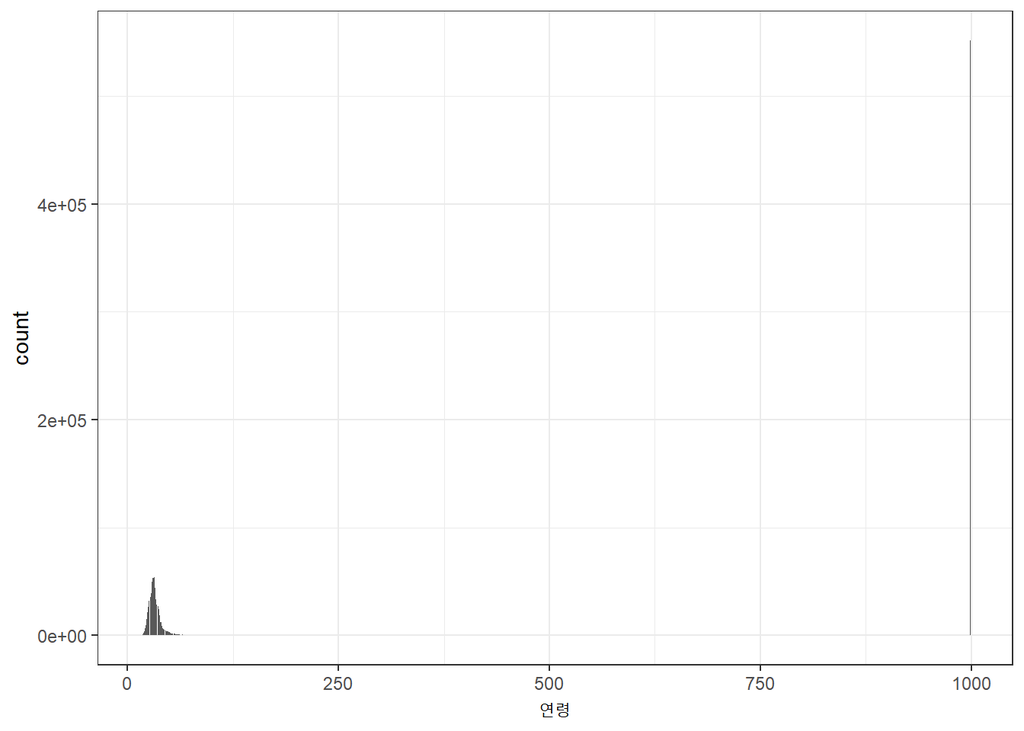

```r
ggplot(data, aes(`연령`)) +
  geom_bar() + theme_bw()
```

```r
# 연령에 이상값 존재함

summary(data$연령)
```

```
##    Min. 1st Qu.  Median    Mean 3rd Qu.    Max.
##    14.0    31.0    42.0   467.6   999.0   999.0
```

```r
data %>% filter(연령==999) %>% group_by(연령, 연령대) %>% count()
```

| 연령 | 연령대 | n |
| --- | --- | --- |
| 999 | z | 551416 |

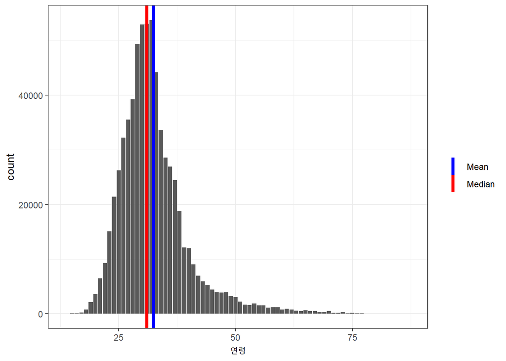

```r
# 연령이 미입력인 경우 연령이 999로 입력됨!

temp <- data %>% filter(`연령`!=999)
colors <- c("Median" = "red", "Mean" = "blue")
ggplot(temp, aes(`연령`)) +
  geom_bar() + theme_bw() +
  geom_vline(aes(xintercept = median(temp$연령), color='Median'), lwd=1.5) +
  geom_vline(aes(xintercept = mean(temp$연령), color='Mean'), lwd=1.5) +
  labs(color = "") +
  scale_color_manual(values = colors)
```

- 연령의 분포는 오른쪽으로 꼬리가 긴 right-skewed 형태임을 확인할 수 있다.

#### 매출액

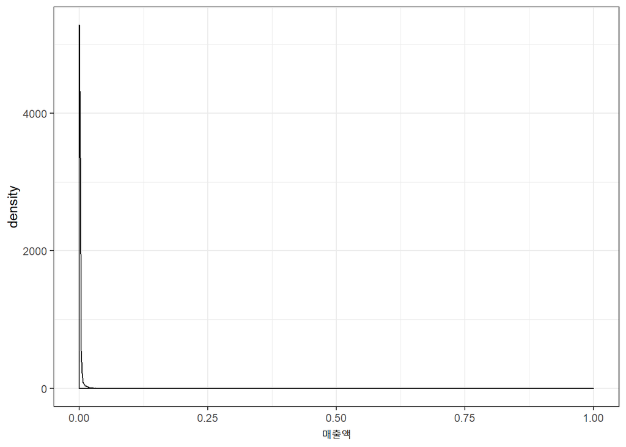

```r
ggplot(data, aes(`매출액`)) +
  geom_density() + theme_bw()
```

```r
summary(data$매출액)
```

```
##    Min. 1st Qu.  Median    Mean 3rd Qu.    Max.    NA's
##       0       0       0       0       0       1   41328
```

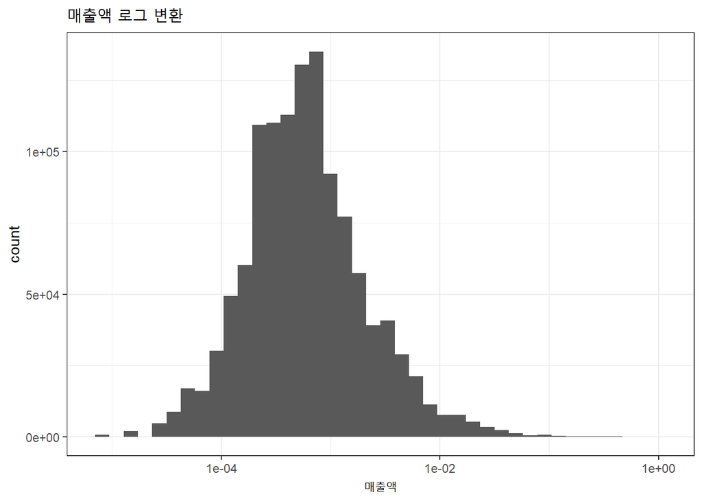

```r
# 매출액이 0근처에 밀집되어 있음

ggplot(data, aes(`매출액`)) +
  geom_histogram(bins = 40) + theme_bw() +
  scale_x_log10() +
  labs(title = '매출액 로그 변환')
```

#### 판매단가

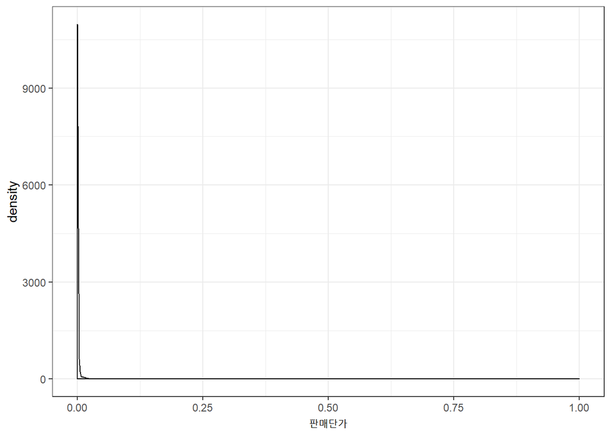

```r
ggplot(data, aes(`판매단가`)) +
  geom_density() + theme_bw()
```

```r
summary(data$판매단가)
```

```
##    Min. 1st Qu.  Median    Mean 3rd Qu.    Max.    NA's
##       0       0       0       0       0       1   41328
```

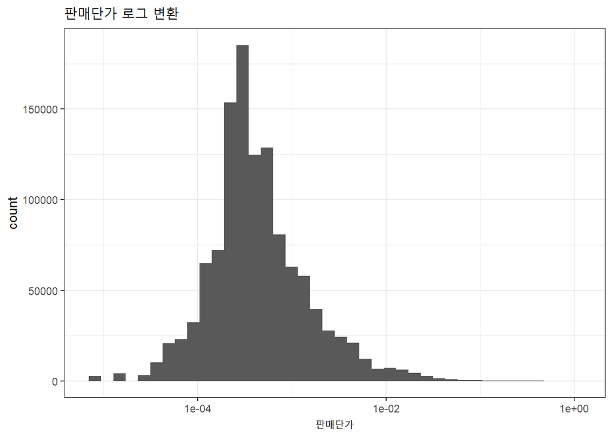

```r
# 판매단가가 0근처에 밀집되어 있음
ggplot(data, aes(`판매단가`)) +
  geom_histogram(bins = 40) + theme_bw() +
  scale_x_log10() +
  labs(title = '판매단가 로그 변환')
```

### Categorical Variables

```r
my_plot <- function(my_data=data, my_var, my_title=''){
  ggplot(my_data, aes(my_var)) +
    geom_bar(aes(fill=my_var)) +
    theme_bw() +
    labs(title = my_title, x = NULL, fill = my_title) +
    theme(axis.text.x = element_text(size = 10))
}
```

#### 성별

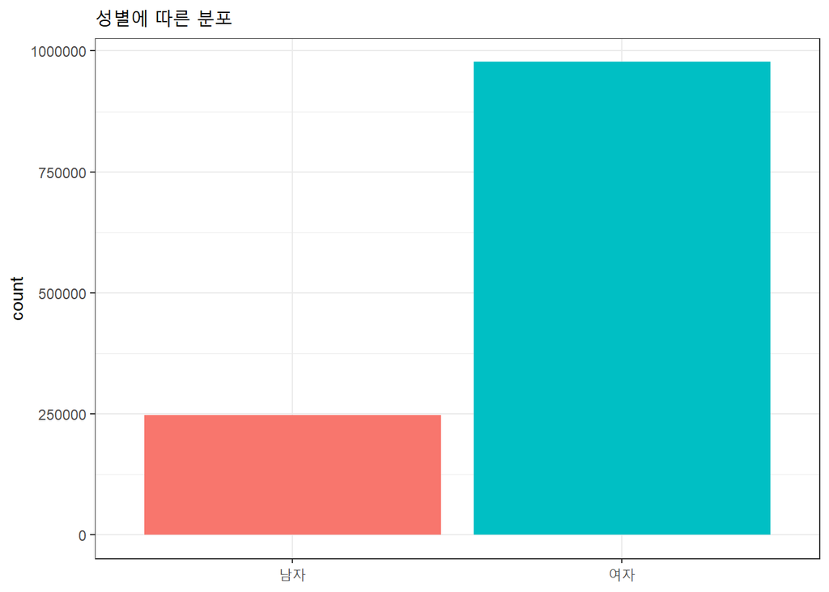

```r
my_plot(data, data$성별, '성별에 따른 분포') +
  scale_x_discrete(breaks = 1:2, labels = c('남자', '여자')) +
  theme(legend.position = 'none')
```

#### 연령대

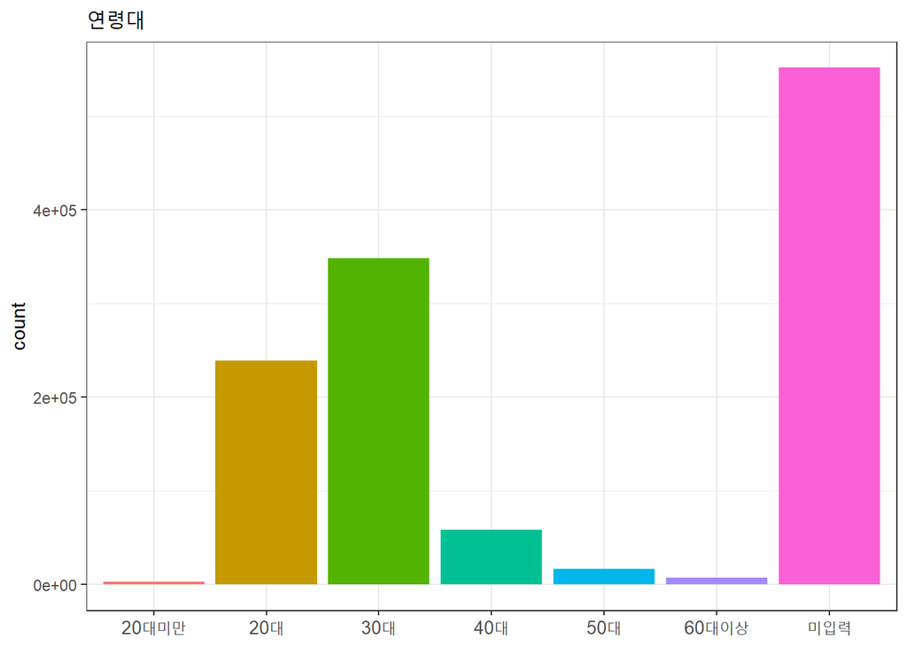

```r
my_plot(data, data$연령대, '연령대') +
  scale_x_discrete(breaks = c(1:6, 'z'),
                   labels = c('20대미만', '20대', '30대', '40대',
                              '50대', '60대이상', '미입력')) +
  theme(legend.position = 'none')
```

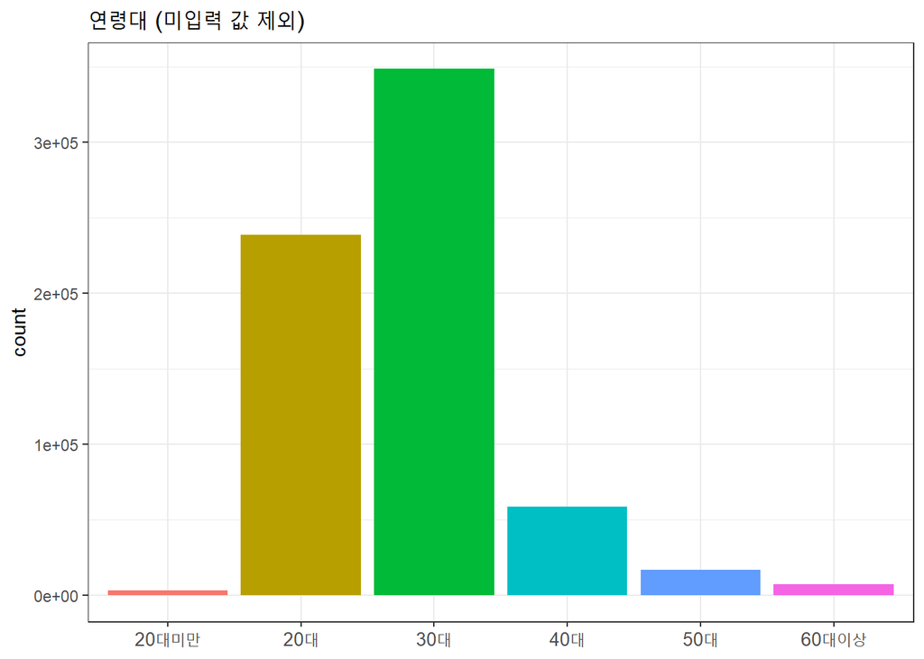

```r
#### 연령대 (미입력 제외)
data1 <- data %>% filter(`연령`!=999)
my_plot(data1 , data1$연령대, '연령대 (미입력 값 제외)') +
  scale_x_discrete(breaks = 1:6,
                   labels = c('20대미만', '20대', '30대', '40대',
                              '50대', '60대이상')) +
  theme(legend.position = 'none')
```

- 미입력을 제외한 주연령층은 20-30대

#### 국가코드

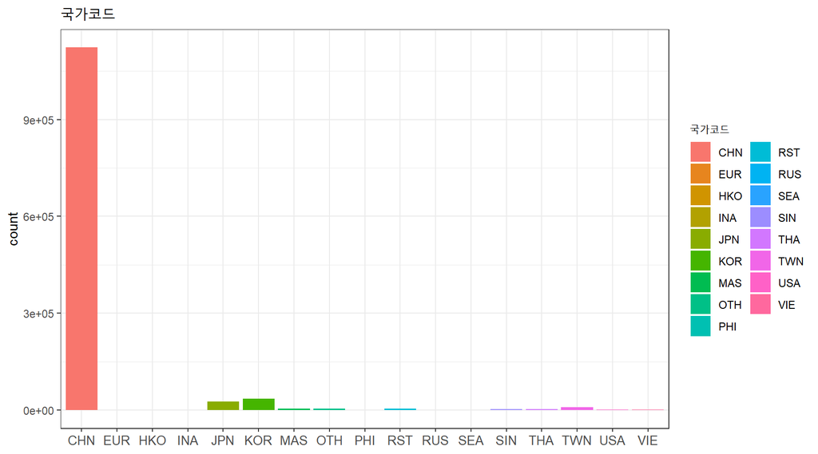

```r
my_plot(data, data$국가코드, '국가코드') +
  guides(fill=guide_legend(ncol=2))
```

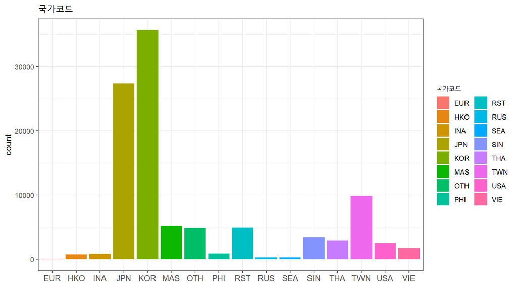

```r
#### 국가코드에서 중국 제외
data1 <- data %>% filter(`국가코드`!='CHN')
my_plot(data1, data1$국가코드, '국가코드') +
  guides(fill=guide_legend(ncol=2))
```

- 중국이 압도적으로 많음!

#### VIP등급

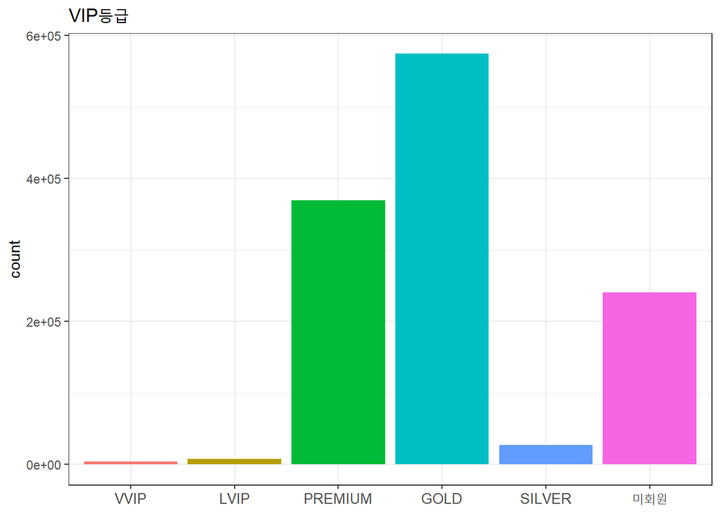

```r
data$VIP등급 <- factor(data$VIP등급,
                   levels = c('V', 'L', 'P', 'G', 'S', 'z'))
my_plot(data, data$VIP등급, 'VIP등급') +
  scale_x_discrete(labels = c('VVIP', 'LVIP', 'PREMIUM', 'GOLD',
                              'SILVER', '미회원')) +
  theme(legend.position = 'none')
```

#### 카테고리코드/카테고리명 (9개 구분)

```r
data1 <- data %>% group_by(카테고리코드, 카테고리명) %>% count()
data1
```

| 카테고리코드 | 카테고리명 | n |
| --- | --- | --- |
| 11 | FASHION | 145592 |
| 12 | COS and PFM | 926949 |
| 13 | JEW and WATCH | 31727 |
| 14 | LEATHER | 27034 |
| 15 | LIQUOR and TOBACCO | 16371 |
| 16 | FOOD | 33511 |
| 17 | ELECTRONICS | 3413 |
| 18 | EYEWEAR | 11751 |
| 19 | ACC and GIFT | 28447 |

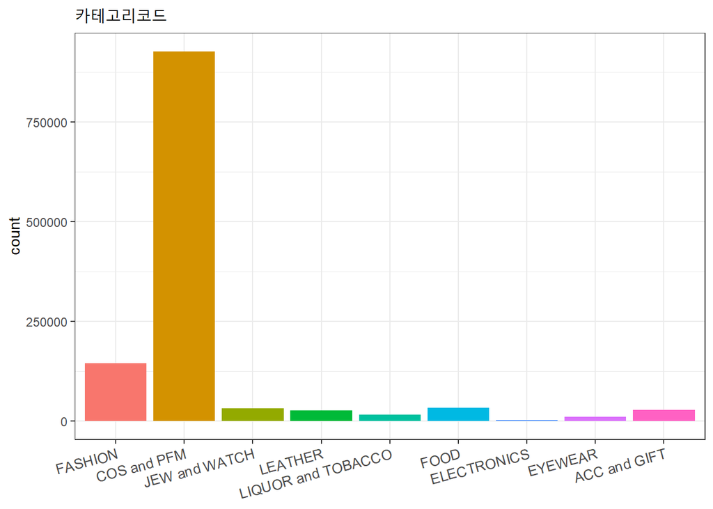

```r
my_plot(data, data$카테고리코드, '카테고리코드') +
  scale_x_discrete(labels = data1$카테고리명) +
  theme(legend.position = 'none',
        axis.text.x = element_text(angle = 15, hjust = 1, vjust = 1))
```

- 화장품과 향수가 압도적으로 많음

#### 아이템코드/아이템명 (25개 구분)

```r
data1 <- data %>% group_by(아이템코드, 아이템명) %>% count()
data1
```

| 아이템코드 | 아이템명 | n |
| --- | --- | --- |
| 1 | 의류 | 50903 |
| 2 | 의류잡화 | 41368 |
| 3 | 신발 | 18687 |
| 4 | LLG | 37071 |
| 5 | SLG | 18412 |
| 6 | 화장품 | 887092 |
| 7 | 향수 | 45714 |
| 8 | 안경 | 11935 |
| 12 | 순보석 | 9860 |
| 13 | 모조보석 | 18613 |

[output cut: 15 more lines]

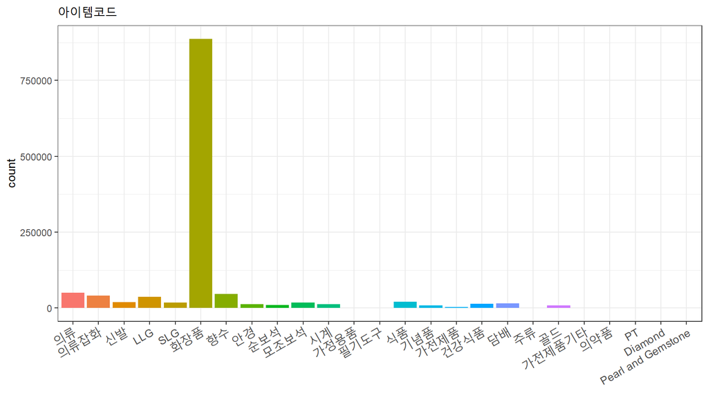

```r
my_plot(data, data$아이템코드, '아이템코드') +
  scale_x_discrete(labels = data1$아이템명) +
  theme(legend.position = 'none',
        axis.text.x = element_text(angle = 30, hjust = 1, vjust = 1))
```

```r
data1 <- data %>% filter(`아이템코드`!=6) %>%
  group_by(아이템코드, 아이템명) %>% count()
data1
```

| 아이템코드 | 아이템명 | n |
| --- | --- | --- |
| 1 | 의류 | 50903 |
| 2 | 의류잡화 | 41368 |
| 3 | 신발 | 18687 |
| 4 | LLG | 37071 |
| 5 | SLG | 18412 |
| 7 | 향수 | 45714 |
| 8 | 안경 | 11935 |
| 12 | 순보석 | 9860 |
| 13 | 모조보석 | 18613 |
| 14 | 시계 | 12702 |

[output cut: 14 more lines]

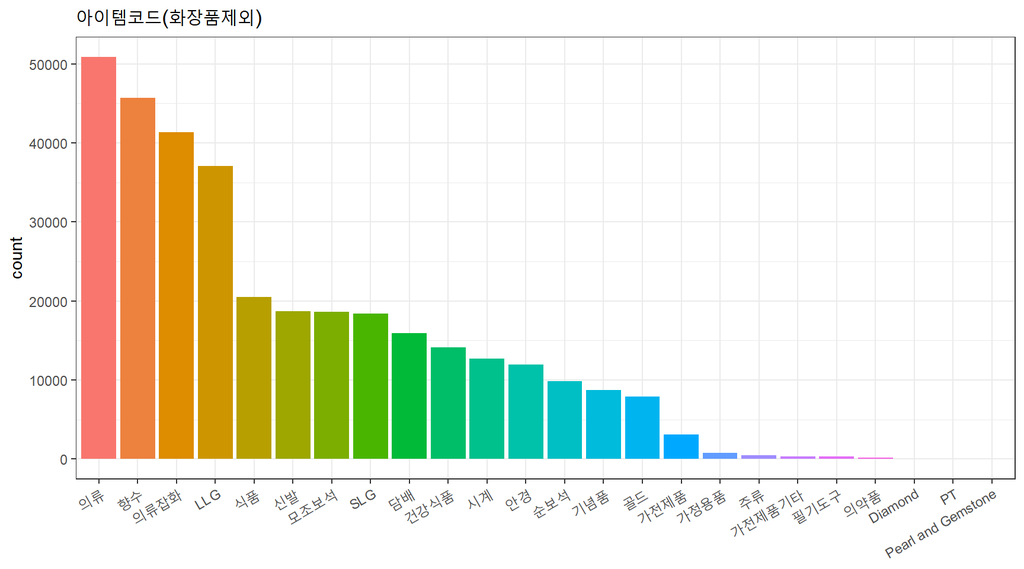

```r
ggplot(data1, aes(reorder(아이템명, -n), n, fill = reorder(아이템명, -n))) +
  geom_bar(stat = 'identity') +
  theme_bw() +
  labs(x = NULL, y = 'count', title = '아이템코드(화장품제외)') +
  theme(legend.position = 'none',
        axis.text.x = element_text(angle = 30, hjust = 1, vjust = 1))
```

- 6번(화장품) 아이템코드가 압도적으로 높음!

#### 클래스코드/클래스명 (55개 구분)

```r
data1 <- data %>% group_by(클래스코드, 클래스명) %>% count()
data1
```

| 클래스코드 | 클래스명 | n |
| --- | --- | --- |
| 1 | Dia (below 1ct) | 44 |
| 1 | Platinum | 5 |
| 1 | 금,은및백금체인 | 3 |
| 1 | 바지,반바지 | 1481 |
| 1 | 벨트,멜빵 | 7341 |
| 1 | 부츠 | 1694 |
| 1 | 안경테 | 646 |
| 1 | 원액기 | 46 |
| 1 | 팔찌,발찌 | 1939 |
| 2 | Dia (above 1ct) | 10 |

[output cut: 172 more lines]